# MS brain age UCL MAGNIMS analysis

## Longitudinal brain-predicted age trajectories

### Interaction between group and time MS vs. controls

Conditional growth model - random effects of participant and cohort

```r
model_int.group <- lmer(BrainPAD ~ control0rest1 * interval + poly(age_at_baseline_scan1, 2) + gender + field_strength + (interval|PatientID) + (1|Cohort), data = df, control = lmerControl(optimizer = "Nelder_Mead"))
round(anova(model_int.group)["control0rest1:interval",],3)
```

```
Type III Analysis of Variance Table with Satterthwaite's method
                       Sum Sq Mean Sq NumDF DenDF F value Pr(>F)
control0rest1:interval   27.7    27.7     1  1326    5.84  0.016 *
---
Signif. codes:  0 ‘***’ 0.001 ‘**’ 0.01 ‘*’ 0.05 ‘.’ 0.1 ‘ ’ 1
```

```r
summary(model_int.group)
```

```
Linear mixed model fit by REML. t-tests use Satterthwaite's method ['lmerModLmerTest']
Formula: BrainPAD ~ control0rest1 * interval + poly(age_at_baseline_scan1,
    2) + gender + field_strength + (interval | PatientID) + (1 |      Cohort)
   Data: df
Control: lmerControl(optimizer = "Nelder_Mead")

REML criterion at convergence: 21373

Scaled residuals:
   Min     1Q Median     3Q    Max
-9.741 -0.358 -0.014  0.345  8.603

Random effects:
 Groups    Name        Variance Std.Dev. Corr
 PatientID (Intercept) 82.887   9.104
           interval     0.461   0.679    -0.06
 Cohort    (Intercept) 15.207   3.900
 Residual               4.738   2.177
Number of obs: 3564, groups:  PatientID, 1354; Cohort, 15

Fixed effects:
                                 Estimate Std. Error        df t value Pr(>|t|)
(Intercept)                        0.0513     1.4471   38.4207    0.04  0.97191
control0rest1MS                   12.1417     1.0279 1258.5379   11.81  < 2e-16 ***
interval                          -0.1655     0.1496 1374.1462   -1.11  0.26873
poly(age_at_baseline_scan1, 2)1  -59.1972    16.3337 1335.7802   -3.62  0.00030 ***
poly(age_at_baseline_scan1, 2)2  -33.7926    14.9329 1340.4326   -2.26  0.02380 *
gendermale                         1.9018     0.5263 1337.0517    3.61  0.00031 ***
field_strength3T                  -3.2593     0.9971  347.0562   -3.27  0.00119 **
control0rest1MS:interval           0.3722     0.1539 1325.5026    2.42  0.01575 *
---
Signif. codes:  0 ‘***’ 0.001 ‘**’ 0.01 ‘*’ 0.05 ‘.’ 0.1 ‘ ’ 1

Correlation of Fixed Effects:
            (Intr) cn01MS intrvl p(___1,2)1 p(___1,2)2 gndrml fld_3T
cntrl0rs1MS -0.613
interval    -0.066  0.093
pl(___1,2)1  0.072 -0.159 -0.001
pl(___1,2)2  0.026 -0.055  0.003  0.026
gendermale  -0.147  0.027  0.003  0.027      0.059
fld_strng3T -0.275  0.024  0.002  0.016     -0.027     -0.041
cntrl0r1MS:  0.063 -0.098 -0.972  0.001     -0.003     -0.003  0.000
```

Use sjPlots to visualise the interactions, using estimated marginal means

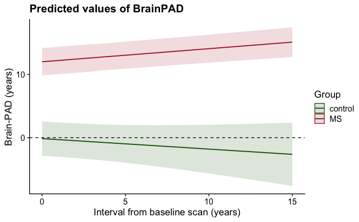

```r
plot_model(model_int.group, type = "emm", terms = c("interval [all]", "control0rest1"), colors = c("darkgreen", "firebrick"), legend.title = "Group", grid = F, show.data = F) + theme_cowplot() + labs(x = "Interval from baseline scan (years)", y = "Brain-PAD (years)") + geom_hline(yintercept = 0, lty = 2)
```

#### Generate estimate marginal trends for healthy controls and for all MS/CIS combined, using annualised difference between baseline and final follow-up.

```r
emtrends(object = model_int.group, pairwise ~ control0rest1, var = "interval")
```

```
$emtrends
 control0rest1 interval.trend    SE  df asymp.LCL asymp.UCL
 control               -0.166 0.150 Inf     -0.46     0.128
 MS                     0.207 0.036 Inf      0.14     0.278

Results are averaged over the levels of: gender, field_strength
Degrees-of-freedom method: asymptotic
Confidence level used: 0.95

$contrasts
 contrast     estimate    SE  df z.ratio p.value
 control - MS    -0.37 0.154 Inf -2.420  0.0156

Results are averaged over the levels of: gender, field_strength
Degrees-of-freedom method: asymptotic
```

### Interaction between group and time MS subtypes

Conditional growth model - random effects of participant and cohort

```r
model_int.subtype <- lmer(BrainPAD ~ subtype * interval + poly(age_at_baseline_scan1, 2) + gender + field_strength + (interval|PatientID) + (1|Cohort), data = subset(df, df$subtype != "control"), control = lmerControl(optimizer = "Nelder_Mead"))
round(anova(model_int.subtype)["subtype:interval",],3)
```

```
Type III Analysis of Variance Table with Satterthwaite's method
                 Sum Sq Mean Sq NumDF DenDF F value Pr(>F)
subtype:interval   78.2    26.1     3   846    4.99  0.002 **
---
Signif. codes:  0 ‘***’ 0.001 ‘**’ 0.01 ‘*’ 0.05 ‘.’ 0.1 ‘ ’ 1
```

```r
emtrends(object = model_int.subtype, pairwise ~ subtype, var = "interval")
```

```
$emtrends
 subtype interval.trend    SE  df asymp.LCL asymp.UCL
 CIS               0.15 0.074 Inf      0.01      0.30
 RRMS              0.24 0.047 Inf      0.15      0.33
 SPMS             -0.26 0.144 Inf     -0.54      0.02
 PPMS              0.42 0.118 Inf      0.19      0.65

Results are averaged over the levels of: gender, field_strength
Degrees-of-freedom method: asymptotic
Confidence level used: 0.95

$contrasts
 contrast    estimate    SE  df z.ratio p.value
 CIS - RRMS     -0.09 0.088 Inf -1.000  0.7300
 CIS - SPMS      0.41 0.162 Inf  2.500  0.0600
 CIS - PPMS     -0.27 0.139 Inf -2.000  0.2000
 RRMS - SPMS     0.50 0.152 Inf  3.300  0.0100
 RRMS - PPMS    -0.18 0.127 Inf -1.400  0.4700
 SPMS - PPMS    -0.68 0.186 Inf -3.700  <.0001

Results are averaged over the levels of: gender, field_strength
Degrees-of-freedom method: asymptotic
P value adjustment: tukey method for comparing a family of 4 estimates
```

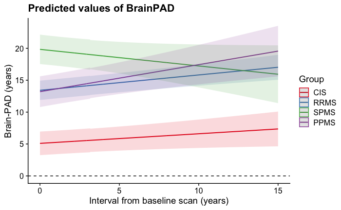

```r
plot_model(model_int.subtype, type = "emm", terms = c("interval [all]", "subtype"), legend.title = "Group", show.data = F, grid = F) + theme_cowplot() + labs(x = "Interval from baseline scan (years)", y = "Brain-PAD (years)") + geom_hline(yintercept = 0, lty = 2)
```

### Longitudinal brain-PAD by interval plots

Randomly sub-sampling 50% of the data.

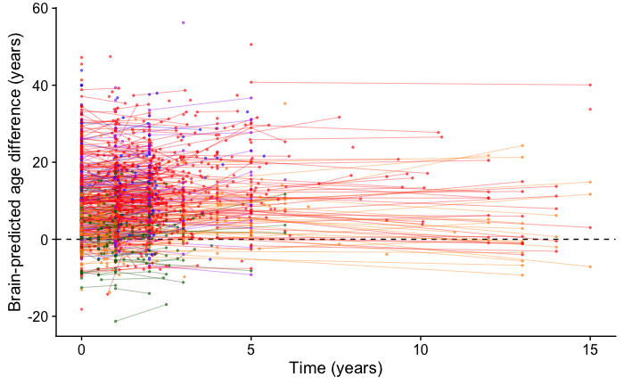

```r
sub.sample.df <- df %>%
  filter(NoScans >= 2)  %>%
  group_by(PatientID) %>%
  sample_frac(0.5) %>%
  ungroup()
ggplot(data = sub.sample.df, aes(x = interval, y = BrainPAD, fill = subtype)) +
  geom_hline(yintercept = 0, lty = 2) +
  geom_line(aes(group = PatientID, colour = subtype), alpha = 0.5, linetype = 1, size = 0.25) +
  geom_point(aes(colour = subtype), size = 0.5, alpha = 0.5) +
  labs(x = "Time (years)", y = "Brain-predicted age difference (years)") +
  scale_fill_manual(values = ms.palette) +
  scale_color_manual(values = ms.palette) +
  # facet_grid(Cohort) +
  theme_cowplot() + theme(legend.position = "none")
ggsave(filename = "~/Work/Brain ageing/Collaborations/MS/plots/longitudinal_brain-PAD_time_plot.pdf", height = 6, width = 6, useDingbats = FALSE)
```

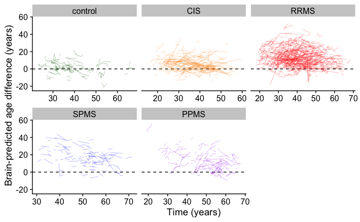

```r
ggplot(data = df, aes(x = age_at_scan, y = BrainPAD, fill = subtype)) +
  geom_hline(yintercept = 0, lty = 2) +
  geom_line(aes(group = PatientID, colour = subtype), alpha = 0.5, linetype = 1, size = 0.2) +
  # geom_smooth(method = "lm", aes(col = subtype)) +
  labs(x = "Time (years)", y = "Brain-predicted age difference (years)") +
  scale_fill_manual(values = ms.palette) +
  scale_color_manual(values = ms.palette) +
  facet_wrap(~ subtype, scales = "free_x") +
  theme_cowplot() + theme(legend.position = "none")
```

## Age at diagnosis and longitudinal brain-PAD

```r
model_int.onset <- lmer(BrainPAD ~ disease_onset_age * interval + poly(age_at_baseline_scan1, 2) + gender + field_strength + (interval|PatientID) + (1|Cohort), data = subset(df, df$control0rest1 == "MS"), control = lmerControl(optimizer = "Nelder_Mead"))
```

```
Some predictor variables are on very different scales: consider rescalingSome predictor variables are on very different scales: consider rescaling
```

```r
anova(model_int.onset)
```

```
Type III Analysis of Variance Table with Satterthwaite's method
                               Sum Sq Mean Sq NumDF DenDF F value  Pr(>F)
disease_onset_age                 937     937     1  1035  175.43 < 2e-16 ***
interval                           38      38     1   696    7.11  0.0079 **
poly(age_at_baseline_scan1, 2)    347     173     2  1044   32.46 2.1e-14 ***
gender                             65      65     1  1127   12.18  0.0005 ***
field_strength                     26      26     1   179    4.87  0.0286 *
disease_onset_age:interval          6       6     1   693    1.06  0.3042
---
Signif. codes:  0 ‘***’ 0.001 ‘**’ 0.01 ‘*’ 0.05 ‘.’ 0.1 ‘ ’ 1
```

## Time since diagnosis and longitudinal brain-PAD

```r
model_int.duration <- lmer(BrainPAD ~ disease_duration * interval + poly(age_at_baseline_scan1, 2) + gender + field_strength + (interval|PatientID) + (1|Cohort), data = subset(df, df$control0rest1 == "MS"), control = lmerControl(optimizer = "Nelder_Mead"))
```

```
Some predictor variables are on very different scales: consider rescalingSome predictor variables are on very different scales: consider rescaling
```

```r
anova(model_int.duration)
```

```
Type III Analysis of Variance Table with Satterthwaite's method
                               Sum Sq Mean Sq NumDF DenDF F value  Pr(>F)
disease_duration                  934     934     1  1014  179.95 < 2e-16 ***
interval                          332     332     1   526   63.90 8.3e-15 ***
poly(age_at_baseline_scan1, 2)    462     231     2  1076   44.56 < 2e-16 ***
gender                             62      62     1  1085   11.87 0.00059 ***
field_strength                     23      23     1   172    4.52 0.03500 *
disease_duration:interval         173     173     1   748   33.27 1.2e-08 ***
---
Signif. codes:  0 ‘***’ 0.001 ‘**’ 0.01 ‘*’ 0.05 ‘.’ 0.1 ‘ ’ 1
```

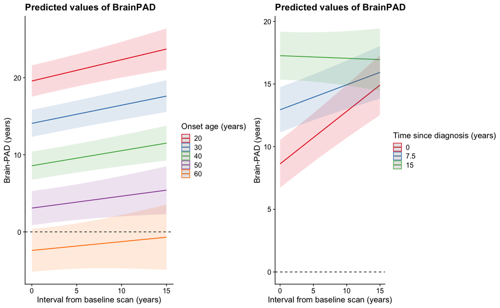

```r
onset.plt <- plot_model(model_int.onset, type = "pred", terms = c("interval [all]", "disease_onset_age[20,30,40,50,60]"), legend.title = "Onset age (years)", show.data = F, grid = F) +
  geom_hline(yintercept = 0, lty = 2) +
  labs(x = "Interval from baseline scan (years)", y = "Brain-PAD (years)") +
  theme_cowplot()
duration.plt <- plot_model(model_int.duration, type = "pred", terms = c("interval [all]", "disease_duration[0,7.5,15]"), legend.title = "Time since diagnosis (years)", show.data = F, grid = F) +
  geom_hline(yintercept = 0, lty = 2) +
  labs(x = "Interval from baseline scan (years)", y = "Brain-PAD (years)") +
  theme_cowplot()
cowplot::plot_grid(onset.plt, duration.plt, nrow = 1)
```

## Plot(s) with age and estimated age for each individual from each group and site

```r
ggplot(data = df, aes(x = age_at_scan, y = BrainAge, fill = subtype)) +
  geom_abline(slope = 1, lty = 2) +
  geom_line(aes(group = PatientID, colour = subtype), alpha = 0.5, linetype = 1, size = 0.25) +
  geom_point(aes(colour = subtype), size = 0.5, alpha = 0.5) +
  labs(x = "Age (years)", y = "Brain-predicted age (years)") +
  scale_fill_manual(values = ms.palette) +
  scale_color_manual(values = ms.palette) +
  facet_wrap(~ Cohort) +
  theme_cowplot() + theme(legend.position = "none")
ggsave(filename = "~/Work/Brain ageing/Collaborations/MS/plots/longitudinal_brain-age_years_plot.pdf", height = 6, width = 10, useDingbats = FALSE)
```